# Project_Capstone_Milestone

Zhengmao Zhu

September 8, 2018

## Introduction

The goal of this project is just to display that you’ve gotten used to working with the data and that you are on track to create your prediction algorithm. Please submit a report on R Pubs (http://rpubs.com/) that explains your exploratory analysis and your goals for the eventual app and algorithm. This document should be concise and explain only the major features of the data you have identified and briefly summarize your plans for creating the prediction algorithm and Shiny app in a way that would be understandable to a non-data scientist manager. You should make use of tables and plots to illustrate important summaries of the data set. The motivation for this project is to: 1. Demonstrate that you’ve downloaded the data and have successfully loaded it in.2. Create a basic report of summary statistics about the data sets.3. Report any interesting findings that you amassed so far.4. Get feedback on your plans for creating a prediction algorithm and Shiny app.

## Load the data

We have texts of blogs, twitter and news of Us, load them first for the further analysis.

```r
library(NLP)
library(tm)
library(wordcloud)
library(RWeka)
library(SnowballC)
library(ggplot2)
library(rtweet)

US_blogs=readLines("C:\\Users\\frozenl\\Desktop\\coursera\\project_capstone\\Coursera_SwiftKey\\en_US\\en_US.blogs.txt", encoding = "UTF-8")
US_twitter=readLines("C:\\Users\\frozenl\\Desktop\\coursera\\project_capstone\\Coursera_SwiftKey\\en_US\\en_US.twitter.txt", encoding = "UTF-8")
US_news=readLines("C:\\Users\\frozenl\\Desktop\\coursera\\project_capstone\\Coursera_SwiftKey\\en_US\\en_US.news.txt", encoding = "UTF-8")
```

## Preprocess the data

We preprocses texts above to get the attributes of them, include the sizes,lengths, characters and words for the data cleaning.

```r
blogs_length=length(US_blogs)
twitter_length=length(US_twitter)
news_length=length(US_news)

blogs_size=file.info("C:\\Users\\frozenl\\Desktop\\coursera\\project_capstone\\Coursera_SwiftKey\\en_US\\en_US.blogs.txt")$size/1024^2
twitter_size=file.info("C:\\Users\\frozenl\\Desktop\\coursera\\project_capstone\\Coursera_SwiftKey\\en_US\\en_US.twitter.txt")$size/1024^2
news_size=file.info("C:\\Users\\frozenl\\Desktop\\coursera\\project_capstone\\Coursera_SwiftKey\\en_US\\en_US.news.txt")$size/1024^2

blogs_nchar=sum(nchar(US_blogs))
twitter_nchar=sum(nchar(US_twitter))
news_nchar=sum(nchar(US_news))

blogs_words=sum(sapply(strsplit(US_blogs, "\\s+"), length))
twitter_words=sum(sapply(strsplit(US_twitter, "\\s+"), length))
news_words=sum(sapply(strsplit(US_news, "\\s+"), length))

text_summary=data.frame(name=c("blogs","twitter","news"),
                        length=c(blogs_length,twitter_length,news_length),
                        size.MB=c(blogs_size,twitter_size,news_size),
                        character=c(blogs_nchar,twitter_nchar,news_nchar),
                        words=c(blogs_words,twitter_words,news_words))
text_summary
```

```
     name  length  size.MB character    words
1   blogs  899288 200.4242 206824505 37334131
2 twitter 2360148 159.3641 162096031 30373543
3    news   77259 196.2775  15639408  2643969
```

## Data cleaning

Considering the size of texts and the memory of my laptop, we only choose parts of them to analyze and save operation time for more exploration.

```r
set.seed(7777)
sample_blogs=sample(US_blogs, 6000, replace=FALSE)
sample_twitter=sample(US_twitter, 6000, replace=FALSE)
sample_news=sample(US_news, 6000, replace=FALSE)
rm(US_blogs)
rm(US_twitter)
rm(US_news)
```

## Build the corpus

We build the corpus to extract the stem document and delete some conjunctions for analyzing the words frequency and relationship.

```r
corpus=function(sample){
    sample1=VCorpus(VectorSource(sample))
    sample2=tm_map(sample1, removeNumbers)
    sample3=tm_map(sample2, removePunctuation)
    sample4=tm_map(sample3, removeWords, stopwords("english"))
    sample5=tm_map(sample4, stripWhitespace)
    sample6=tm_map(sample5, stemDocument)
    sample7=tm_map(sample6, content_transformer(tolower))
    return(sample7)
}

sample_twitter=iconv(sample_twitter, "UTF-8", "ASCII")
blogs=corpus(clean_tweets(sample_blogs))
twitter=corpus(clean_tweets(sample_twitter))
news=corpus(clean_tweets(sample_news))
```

## Summary the corpus

We conclude the words frequency and plot the wordcloud of high frequency words for display.

```
 time  make   day  year  love peopl
  697   568   457   450   437   421
count
   1    2    3    4    5    6    7    8    9   10
8244 2232 1047  684  471  321  263  232  154  144
```

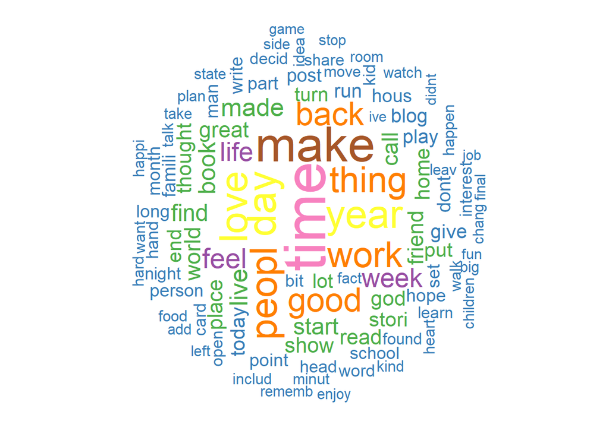

```r
distribution=function(text){
    tdm=TermDocumentMatrix(text)
    count=rowSums(as.matrix(tdm))
    print(head(sort(count, decreasing = T)))
    print(head(table(count), 10))
    wordcloud(text, max.words = 100, random.order = FALSE,rot.per=0.37,
              use.r.layout=FALSE,colors=brewer.pal(8, "Set1"))

}

distribution(blogs)
```

```r
distribution(twitter)
```

```
 love  good   day  time today great
  308   262   237   201   190   183
count
   1    2    3    4    5    6    7    8    9   10
4863 1067  500  334  214  148  130   99   65   72
```

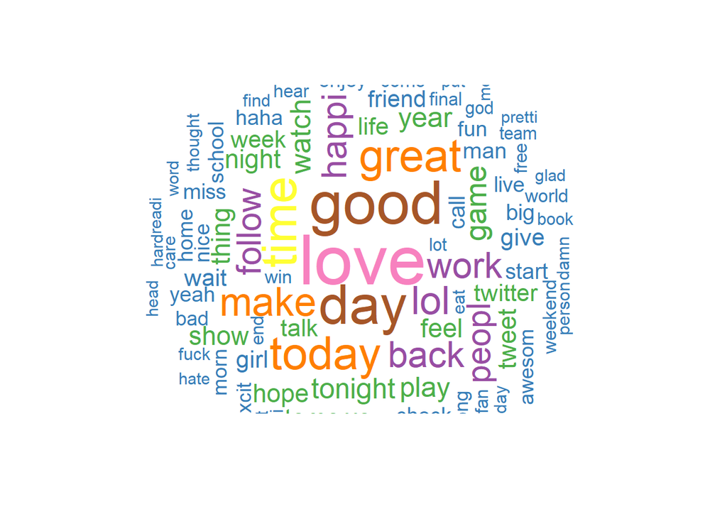

```r
distribution(news)
```

```
 year  time state  work  make  game
  653   391   379   319   318   301
count
   1    2    3    4    5    6    7    8    9   10
8402 2272 1101  672  440  324  279  205  166  134
```

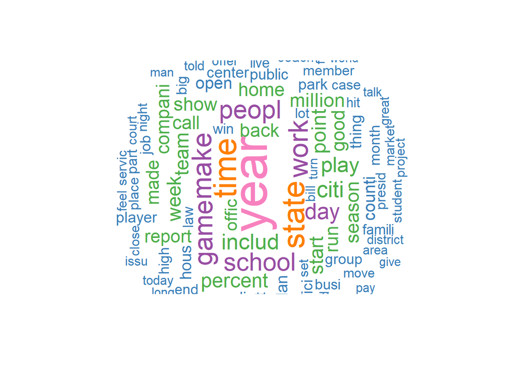

## Build n_gram models and show the plots

We use the histogram to analyze the words relationship and the frequency of phrase. Considering we want to explore the relationship of phrase, so in the 2-gram and 3-gram models, we cannot remove the conjunction.

```
      words frequency
time   time       697
make   make       568
day     day       457
year   year       450
love   love       437
peopl peopl       421
work   work       395
thing thing       394
good   good       361
back   back       349
```

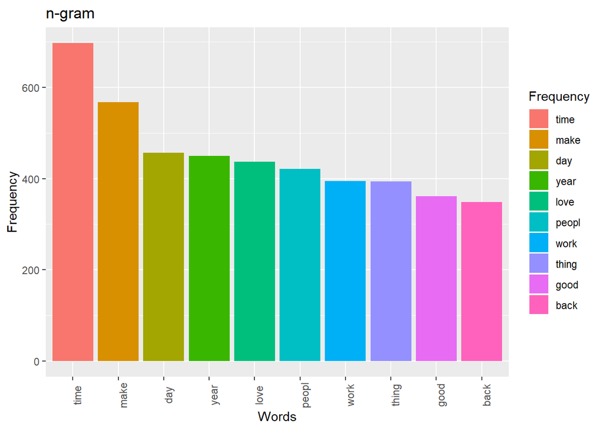

```r
n_gram=function(n,sample_deal){
    m=function(x) NGramTokenizer(x, Weka_control(min=n, max=n))
    m_table=TermDocumentMatrix(sample_deal, control=list(tokenize=m))
    m_corpus=findFreqTerms(m_table)
    m_corpus_num=rowSums(as.matrix(m_table[m_corpus,]))
    m_corpus_table=data.frame(words=names(m_corpus_num),frequency=m_corpus_num)
    m_corpus_sort=m_corpus_table[order(-m_corpus_table$frequency),]
    result=m_corpus_sort[1:10,]
    print(result)
    n_g=ggplot(result,aes(x=reorder(words,-frequency),y=frequency,fill=factor(reorder(words,-frequency))))
    n_g=n_g+geom_bar(stat="identity")
    n_g=n_g+labs(title="n-gram",x="Words",y="Frequency",fill="Frequency")
    n_g=n_g+theme(axis.text.x=element_text(angle=90))
    return(n_g)
}

bi_blogs=corpus(sample(sample_blogs, 2000, replace=FALSE))
bi_twitter=corpus(sample(sample_twitter, 2000, replace=FALSE))
bi_news=corpus(sample(sample_news, 2000, replace=FALSE))

tri_blogs=corpus(sample(sample_blogs, 2000, replace=FALSE))
tri_twitter=corpus(sample(sample_twitter, 2000, replace=FALSE))
tri_news=corpus(sample(sample_news, 2000, replace=FALSE))

n_gram(1,blogs)
```

```r
n_gram(2,bi_blogs)
```

```
          words frequency
i think i think        53
i can     i can        50
i will   i will        39
i want   i want        38
i dont   i dont        29
i just   i just        29
i love   i love        29
i know   i know        26
i hope   i hope        23
i still i still        23
```

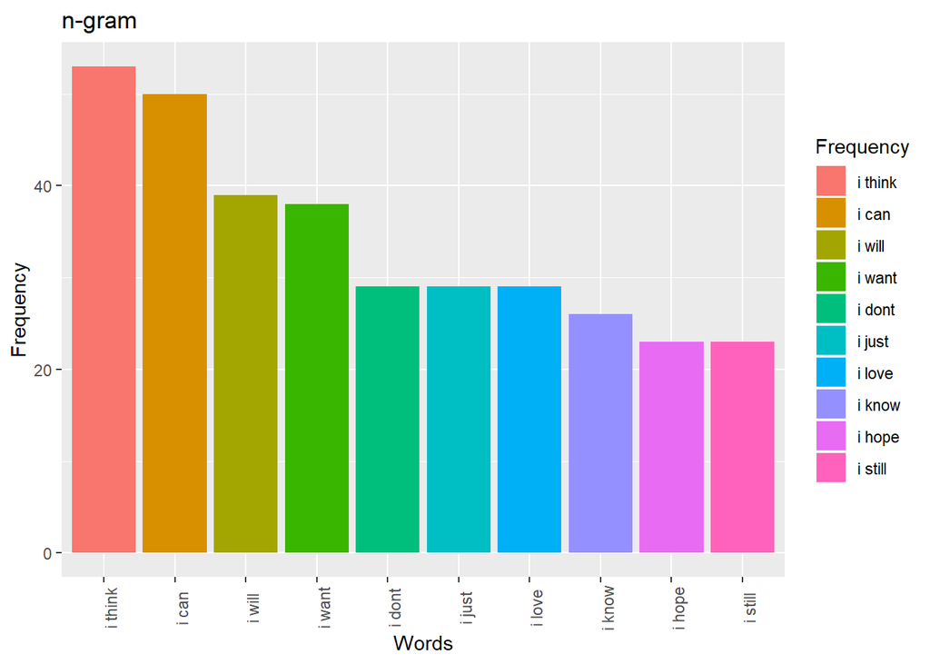

```r
n_gram(3,tri_blogs)
```

```
                  words frequency
i feel like i feel like        10
e e e             e e e         9
i know i       i know i         7
i think i     i think i         7
feel like i feel like i         6
of cours i   of cours i         6
i knew i       i knew i         5
c c c             c c c         4
i can see     i can see         4
i thought i i thought i         4
```

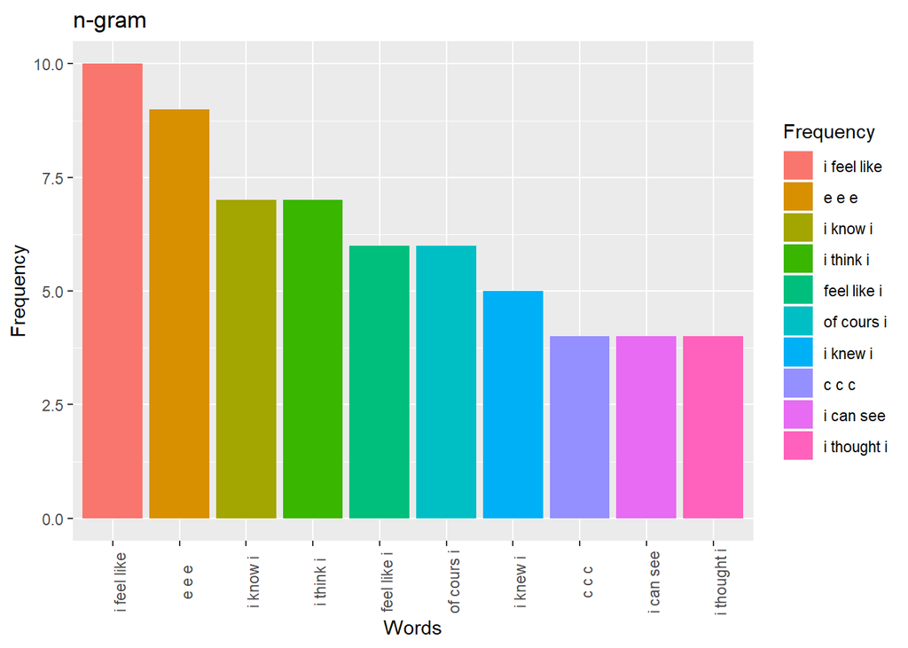

```r
n_gram(1,twitter)
```

```
      words frequency
love   love       308
good   good       262
day     day       237
time   time       201
today today       190
great great       183
make   make       156
lol     lol       153
work   work       141
back   back       139
```

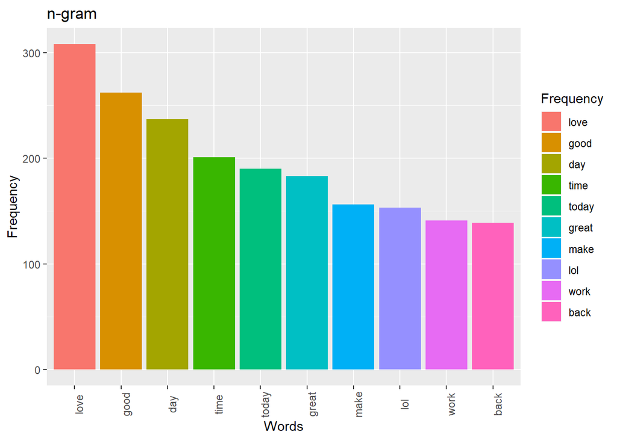

```r
n_gram(2,bi_twitter)
```

```
                    words frequency
i love             i love        25
i dont             i dont        21
i will             i will        16
i got               i got        15
i think           i think        15
i want             i want        15
i just             i just        14
thank follow thank follow        14
feel like       feel like        13
i get               i get        12
```

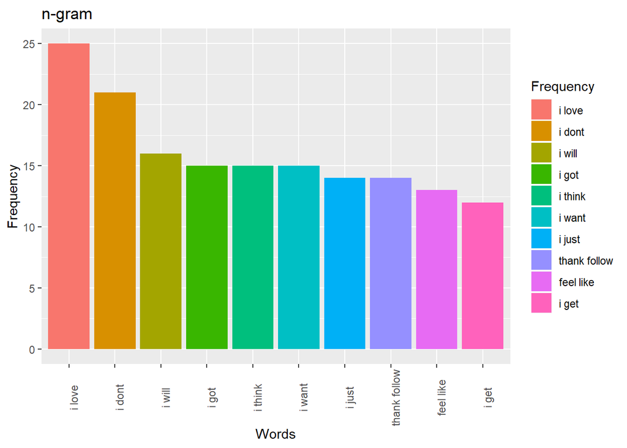

```r
n_gram(3,tri_twitter)
```

```
                            words frequency
i feel like           i feel like         4
i wish i                 i wish i         4
cant wait see       cant wait see         3
cant wait till     cant wait till         3
i dont know           i dont know         3
i just want           i just want         3
i love i                 i love i         3
best place world best place world         2
cant wait get       cant wait get         2
contest i forgot contest i forgot         2
```

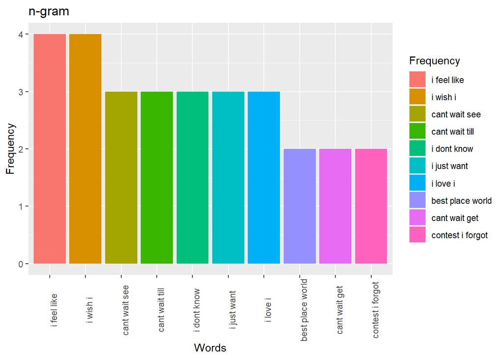

```r
n_gram(1,news)
```

```
        words frequency
year     year       653
time     time       391
state   state       379
work     work       319
make     make       318
game     game       301
peopl   peopl       289
school school       283
day       day       247
citi     citi       242
```

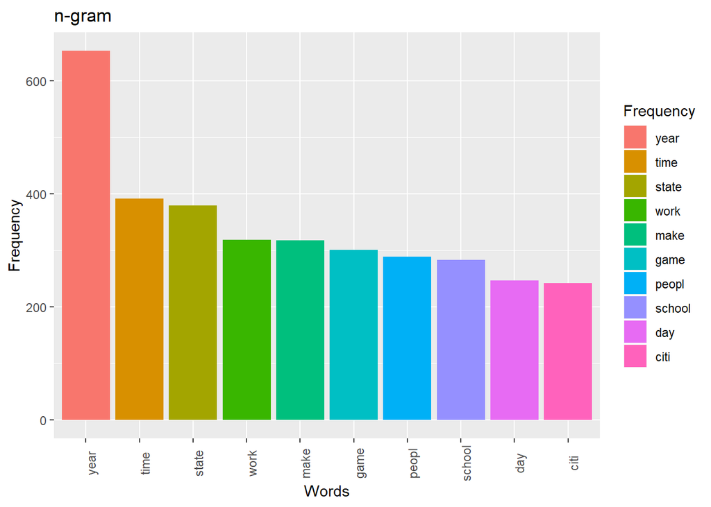

```r
n_gram(2,bi_news)
```

```
                  words frequency
last year     last year        33
i think         i think        26
new york       new york        23
last week     last week        22
year ago       year ago        22
he said         he said        16
i dont           i dont        16
new jersey   new jersey        16
high school high school        15
he also         he also        13
```

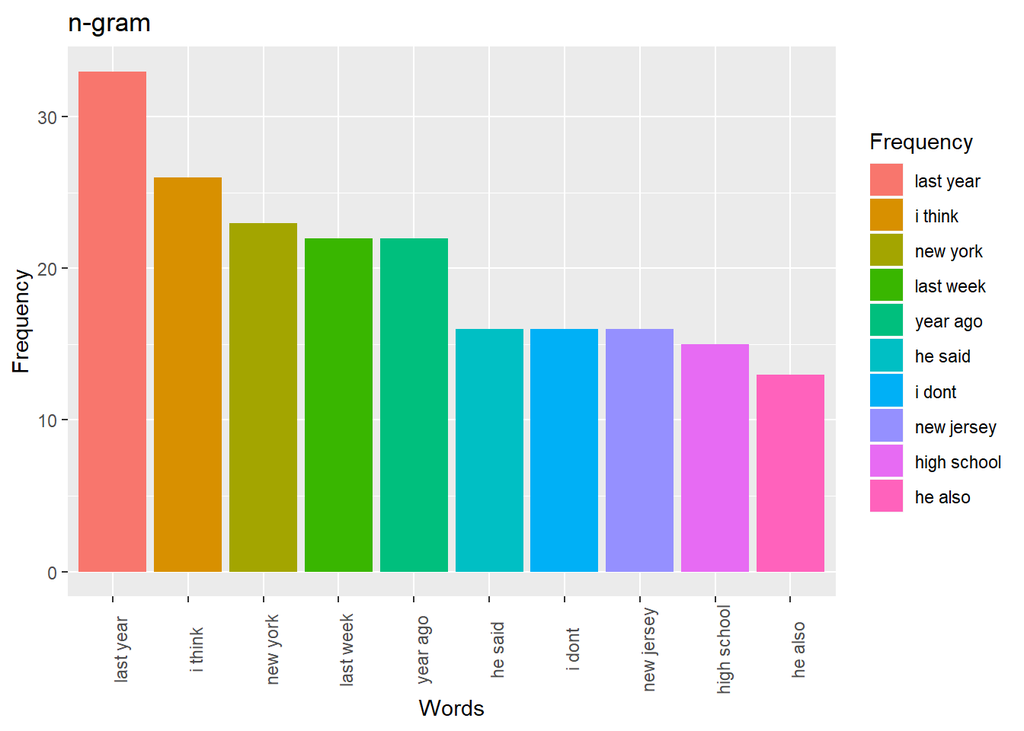

```r
n_gram(3,tri_news)
```

```
                                        words frequency
i dont think                     i dont think         4
i think i                           i think i         4
averag fee year               averag fee year         3
game pm espn                     game pm espn         3
i dont want                       i dont want         3
new york new                     new york new         3
said written statement said written statement         3
the averag fee                 the averag fee         3
will take place               will take place         3
accord investig report accord investig report         2
```

[figure not shown]

## Next plan

We hope to continue remove the words meaningless and build prediction algorithm (including n-gram modeland other models) with limited parts of texts and Shiny app. Finally, based on our algorithm, we input the text in our Shiny app, then we can predict the text we want.